# Coursework Report

*N* removed NAs: 3

*N* removed <18: 16

*N* total clean: 128

| Group | *N* | *M*<sub>age</sub> | *M*<sub>rating</sub> |
| --- | --- | --- | --- |
| Control | 68 | 20.5 | 5.96 |
| Experim | 60 | 20.7 | 6.79 |

**Main analysis results**

*t*(126) = -6.91, *p* < .001

# Coursework Report

Analysing Data, Spring 2020

# Methods

## Participants

**Figure 1: Summary of participants age**

| Condition | *Mean*<sub>Age</sub> | *N* | *SD*<sub>Age</sub> | *Mix*<sub>Age</sub> | *Man*<sub>Age</sub> |
| --- | --- | --- | --- | --- | --- |
| White | 20.5 | 68 | 1.57 | 18 | 24 |
| Red | 20.7 | 60 | 2.00 | 18 | 27 |

## Design

This study was designed as a replication of Experiment 1 of Elliot et al. (2010) with the aim of testing its findings - whether red has a positive impact on people’s perception of men’s attractiveness.

As in the original study the participants were required to look at a monochromatic picture of a moderately attractive Caucasian man with brown hair and plain t-shirt for 5 seconds and then had to answer three questions. The pictures were 4 by 6 inches and featured only the head and upper torso of the man. They were placed on a background - 8.5 by 11 inches and depending on the experimental condition it was either white (absence of colour in Photoshop) or red(LCh(49.6, 58.8, 30.4)).

The study employed a between-subject experimental design. The key independent variable was condition which had two levels (control - white, experimental - red). The key dependent variable was perceived attractiveness. It was measured in the same way as in Elliot et al. (2010) - by a creating a composite score for each participant out of their answers on three questions. The questions were “How attractive do you think this person is?”, “How pleasant is this person to look at?” and “If I were to meet the person in this picture face to face, I would think he is attractive.” The participants had to answer the questions on a scale from 1 to 9. Where 1 was “not at all attractive” and 9 was “extremely attractive”.

It was expected that the scores for perceived attractiveness would be higher in the red condition than in the white condition. This prediction was examined with the use of an independent samples *t* test to compare the scores in both conditions.

# Results

The scores from each participant on the three questions measuring attractiveness were added up and then divided by three. This produced a composite score labled perceived attractiveness. After comparing these new scores and their frequencies across the two conditions, the mean scores in the white group turned out to be lower than those in the red one (M = 5.96, 6.79 ; SD=0.69, 0.66; 95% CI [5.79][6.13], [6.62][6.96] respectively).

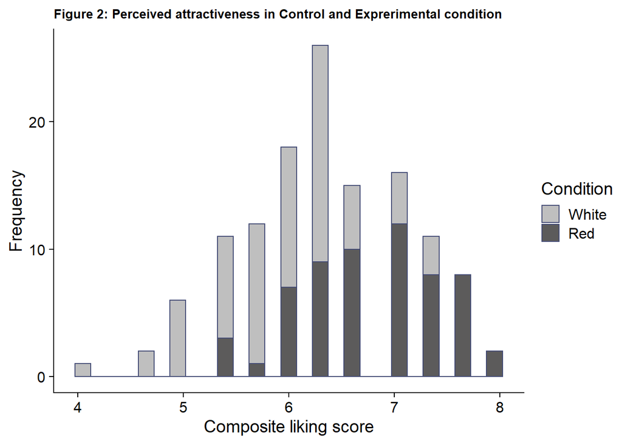

An independent samples *t* test was utilised to examine the significance of the difference in the perceived attractiveness score between the two groups. It showed that there is a significant difference between the means in the two conditions (*M*<sub>diff</sub> = -0.83, 95% CI [-1.07][-0.59]) and that there was a significant difference between the two groups in the composite score of perceived attractiveness (*t* (126) = -6.91, p = < .001). These results rejected the null hypothesis. As predicted red appeared to have a positive influence on the participants’ ratings of the man’s attractiveness.

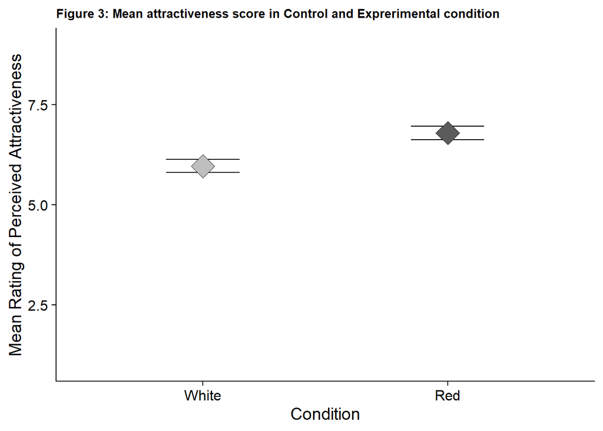

# Discussion

This study was designed as replication to Elliot et al. (2010) in order to test whether red has a positive effect on the perception of men’s attractiveness. The participants in this experiment were presented with a picture of a man with either white or red border depending on the condition and then had to rate th man’s attractiveness by answering three questions. Each participant’s answers were combined to form a single score for perceived attractiveness. After examining the relationship between the new scores and the condition, it turned out that those scores in the white condition were significantly lower than those in the red condition. This finding supported the idea that people view man in relation to the colour red as more attractive. Furthermore, the original findings of Elliot et al. were also supported.

Even though a perfect replication is impossible this study was maximally close the original one. Any differences in this experiment’s design can be attributed to this experiment not accounting for the participants’ gender or possible other unaccounted for variables in both experiments. Having said that, some of the main criticism of Elliot et al. concerning publication bias was taken into account and addressed. In his commentary Francis (2013) argued that the small sample sizes in Elliot et al. (2010) should be accompanied with less stable results across experiments. The current study made sure to use a large sample, thus making sure that any results derived from it are statistically significant and also adding ground to the significance of the original findings.

Elliot and Maier (2013) also tried to address this criticism by replicating Experiment 3 from their original study with a large sample size. They found difference between control and red condition, however this difference was not significant (but still the perceived attractiveness scores in the red condition were higher than those in the white one). This might not be seen as supporting evidence for this replication. However, the data from both experiments shows a positive relationship between the scores for perceived attractiveness and the experimental condition. Additionally, given that this replication was of Experiment 1 (not 3) and that it did not account for the participants’ gender that leaves room for difference in the results. Yet, another possible explanation may come from the fact that both of this experiments only accounted for the results of the red effect and not for the underling mechanisms that produce it. That is why the current study’s findings can be used as supporting evidence for red having an effect on man’s perceived attractiveness, but not for more general implications of red effect on people’s perception.

The ecological validity of this experiment might be one of the limitations that hold the key to finding out how red effects people’s perceptions. This experiment used red frame as a stimulus in the experimental condition, however in the real world the colour red is usually incorporated more naturally into a scene - being in the colour of a piece of clothing, piece of furniture or an accessory. A study done by Okamura (2017) showed that red backgrounds can have an effect on people’s perceptions of a picture in different social situations. This brings light to the possibility of red effect occurring solely because it was examined as a background feature. Thus if red backgrounds are generally stimulating that have an effect on people’s overall perception of an image, this may lead to the assumption that the effect on male attractiveness is a secondary feature. That is why, future studies should replicate the experiments from the original Elliot et al. (2010) study which relied on manipulating the t-shirt colour of the man in the picture for the different conditions.

Other ways in which the ecological validity could be increased is by taking into account and manipulating social cues are present and hold significance in real life situation. Such a cue may be the relative attractiveness of the man in the picture. When it comes to female perceived attractiveness, red has proven itself as a positive influence only for females who are already perceived as attractive (Young, 2015). It is possible that the same effect is present for man as well. That is why, future replications of the current experiment may need to include an additional second control condition in which the participants would be presented with a picture of an unattractive man.

Social cues may mediate red effect in terms not only of whether it is expressed or not but also in terms of how it is expressed - what aspects of a person’s perception it influences. This is supported by the inconsistent replications of the original experiment. For example, Wen et al. (2014) did not succeed in replicating the findings from Elliot et al. They proposed that unaccounted for social cues were the possible reason for that, because they may have facilitated red’s effect on perceived aggression which may have shadowed the one on attractiveness. Additionally, Stephen et al. (2012) showed that when women were asked to make a man’s face as attractive as possible by increasing or decreasing its redness, the women didn’t increase the redness significantly. That was because too much redness could make a man appear aggressive rather than attractive.

Future studies should try to examine red effect as dependent on the social context by also considering red’s possible varying effects and how they affect one another. A good idea might be to ask participants to rate a specific set of a man’s characteristics which are expected to be affected by red in different conditions. Each condition would have to be designed as a social situation that stimulates the association with one of the chosen characteristics. Then by comparing the scores across conditions it might be possible to access whether red effect is dependent on the social situation and whether red has one main effect that could shadow the others.

In conclusion, this replication adds to the growing number studies done on topic of red’s effect on attractiveness. It further solidifies the notion that red has an effect on people’s perceptions. A significant positive relationship between red and the judgement of man’s attractiveness was found. However, the mechanisms which are responsible for this outcome are not yet clear and need further investigation. A possible explanation may be found in red-effect’s dependence on social cues. That is why, it might be a good idea for follow up research to focus on increasing the ecological validity of the experiments by utilising more stimulating and dynamic experimental designs.

# References

Elliot, A. J., & Maier, M. A. (2013). The red-attractiveness effect, applying the Ioannidis and Trikalinos (2007b) test, and the broader scientific context: A reply to Francis (2013). *Journal of Experimental Psychology: General, 142*(1), 297–300. http://dx.doi.org/10.1037/a0029592

Elliot, A. J., Niesta Kayser, D., Greitemeyer, T., Lichtenfeld, S., Gramzow, R. H., Maier, M. A., & Liu, H. (2010). Red, rank, and romance in women viewing men. *Journal of Experimental Psychology: General, 139*(3), 399–417. http://dx.doi.org/10.1037/a0019689

Francis, G. (2013). Publication bias in “Red, rank, and romance in women viewing men,” by Elliot et al. (2010). *Journal of Experimental Psychology: General, 142*(1), 292–296. http://dx.doi.org/10.1037/a0027923

Okamura, Y. (2017). The Influence of the Background Color “Red” on the Appraisal of Pictures. *International Journal of Psychology and Educational Studies, 4*(2), 1–9. https://doi.org/10.17220/ijpes.2017.02.001

Stephen, I., Oldham, F., Perrett, D., & Barton, R. (2012). Redness Enhances Perceived Aggression, Dominance and Attractiveness in Men’s Faces. *Evolutionary Psychology : An International Journal of Evolutionary Approaches to Psychology and Behavior, 10*, 562–572. https://doi.org/10.1177/147470491201000312

Wen, F., Zuo, B., Wu, Y., Sun, S., & Liu, K. (2014). Red is Romantic, but Only for Feminine Females: Sexual Dimorphism Moderates Red Effect on Sexual Attraction. *Evolutionary Psychology, 12*(4), 147470491401200420. https://doi.org/10.1177/147470491401200404

Young, S. G. (2015). The effect of red on male perceptions of female attractiveness: Moderation by baseline attractiveness of female faces: Red and attractiveness. *European Journal of Social Psychology, 45*(2), 146–151. https://doi.org/10.1002/ejsp.2098